# Análise Exploratória de Dados da Educação Superior em R

# 3.7.2 Faixa Etária

Realizamos a análise a seguir com o intuito de mostrar a distribuição dos alunos por faixa etária.

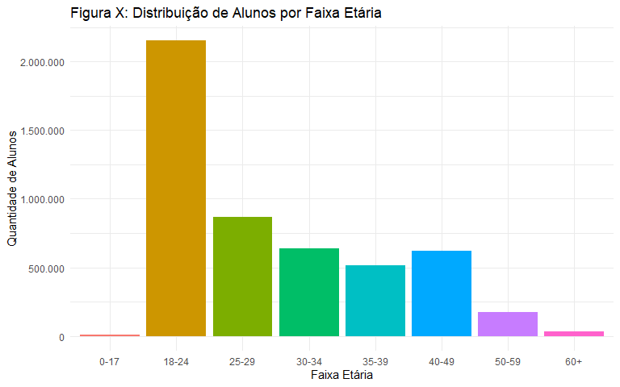

```r
library(scales)  # garante que a função label_comma esteja disponível

faixa_etaria <- cadastro_cursos %>%
  summarise(
    `0-17`   = sum(QT_ING_0_17, na.rm = TRUE),
    `18-24`  = sum(QT_ING_18_24, na.rm = TRUE),
    `25-29`  = sum(QT_ING_25_29, na.rm = TRUE),
    `30-34`  = sum(QT_ING_30_34, na.rm = TRUE),
    `35-39`  = sum(QT_ING_35_39, na.rm = TRUE),
    `40-49`  = sum(QT_ING_40_49, na.rm = TRUE),
    `50-59`  = sum(QT_ING_50_59, na.rm = TRUE),
    `60+`    = sum(QT_ING_60_MAIS, na.rm = TRUE)
  ) %>%
  pivot_longer(cols = everything(),
               names_to = "Faixa_Etaria",
               values_to = "Quantidade")

ggplot(faixa_etaria, aes(x = Faixa_Etaria, y = Quantidade, fill = Faixa_Etaria)) +
  geom_col() +
  labs(
    title = "Figura X: Distribuição de Alunos por Faixa Etária",
    x = "Faixa Etária",
    y = "Quantidade de Alunos"
  ) +
  scale_y_continuous(labels = label_comma(big.mark = ".", decimal.mark = ",")) +
  theme_minimal() +
  theme(legend.position = "none")
```

A maioria dos alunos que iniciam a graduação estão na faixa etária de 18 a 24 anos, ultrapassando 2 milhões. As faixas de 25 a 39 anos também apresentam números expressivos, indicando presença significativa de adultos jovens no sistema educacional. Já os extremos de 0-17 e acima de 50 anos, têm participação muito menor. Isso revela que o ensino superior é majoritariamente frequentado por jovens adultos.

# 3.7.3 Etnia

A seguir a composição étnica dos alunos.

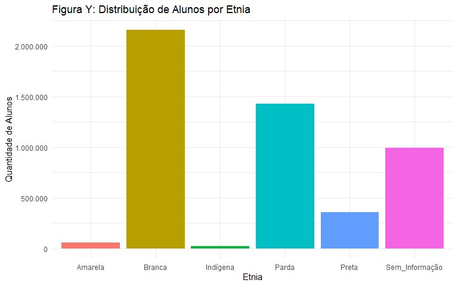

```r
library(scales)  # garante que label_comma esteja disponível

etnia <- cadastro_cursos %>%
  summarise(
    Branca = sum(QT_ING_BRANCA, na.rm = TRUE),
    Preta = sum(QT_ING_PRETA, na.rm = TRUE),
    Parda = sum(QT_ING_PARDA, na.rm = TRUE),
    Amarela = sum(QT_ING_AMARELA, na.rm = TRUE),
    Indígena = sum(QT_ING_INDIGENA, na.rm = TRUE),
    Sem_Informação = sum(QT_ING_CORND, na.rm = TRUE)
  ) %>%
  pivot_longer(cols = everything(),
               names_to = "Etnia",
               values_to = "Quantidade")

ggplot(etnia, aes(x = Etnia, y = Quantidade, fill = Etnia)) +
  geom_col() +
  labs(
    title = "Figura Y: Distribuição de Alunos por Etnia",
    x = "Etnia",
    y = "Quantidade de Alunos"
  ) +
  scale_y_continuous(labels = label_comma(big.mark = ".", decimal.mark = ",")) +
  theme_minimal() +
  theme(legend.position = "none")
```